# IDeA,EFA: Cross Validation TADPOLE

Jose Tamez

2023-02-06

# 1 TADPOLE EFA/IDeA

### 1.0.1 Loading the libraries

```r
library("FRESA.CAD")
library(psych)
library(whitening)
library("vioplot")

library(readxl)
op <- par(no.readonly = TRUE)
pander::panderOptions('digits', 3)
pander::panderOptions('table.split.table', 400)
pander::panderOptions('keep.trailing.zeros',TRUE)
```

## 1.1 The data set

```r
TADPOLE_D1_D2 <- read.csv("~/GitHub/BSWiMS/Data/TADPOLE/TADPOLE_D1_D2.csv")
TADPOLE_D1_D2_Dict <- read.csv("~/GitHub/BSWiMS/Data/TADPOLE/TADPOLE_D1_D2_Dict.csv")
TADPOLE_D1_D2_Dict_LR <- as.data.frame(read_excel("~/GitHub/BSWiMS/Data/TADPOLE/TADPOLE_D1_D2_Dict_LR.xlsx",sheet = "LeftRightFeatures"))


rownames(TADPOLE_D1_D2_Dict) <- TADPOLE_D1_D2_Dict$FLDNAME
```

## 1.2 Conditioning the data

```r
# mm3 to mm
isVolume <- c("Ventricles","Hippocampus","WholeBrain","Entorhinal","Fusiform","MidTemp","ICV",
              TADPOLE_D1_D2_Dict$FLDNAME[str_detect(TADPOLE_D1_D2_Dict$TEXT,"Volume")]
              )


#TADPOLE_D1_D2[,isVolume] <- apply(TADPOLE_D1_D2[,isVolume],2,'^',(1/3))
TADPOLE_D1_D2[,isVolume] <- TADPOLE_D1_D2[,isVolume]^(1/3)

# mm2 to mm
isArea <- TADPOLE_D1_D2_Dict$FLDNAME[str_detect(TADPOLE_D1_D2_Dict$TEXT,"Area")]
TADPOLE_D1_D2[,isArea] <- sqrt(TADPOLE_D1_D2[,isArea])

# Get only cross sectional measurements
FreeSurfersetCross <- str_detect(colnames(TADPOLE_D1_D2),"UCSFFSX")

# The subset of baseline measurements
baselineTadpole <- subset(TADPOLE_D1_D2,VISCODE=="bl")
table(baselineTadpole$DX)
```

```
                   Dementia Dementia to MCI             MCI MCI to Dementia
          7             336               1             864               5
  MCI to NL              NL       NL to MCI
          2             521               1
```

```r
table(baselineTadpole$DX_bl)
```

AD CN EMCI LMCI SMC 342 417 310 562 106

```r
rownames(baselineTadpole) <- baselineTadpole$PTID


validBaselineTadpole <- cbind(DX=baselineTadpole$DX_bl,
                                 AGE=baselineTadpole$AGE,
                                 Gender=1*(baselineTadpole$PTGENDER=="Female"),
                                 ADAS11=baselineTadpole$ADAS11,
                                 ADAS13=baselineTadpole$ADAS13,
                                 MMSE=baselineTadpole$MMSE,
                                 RAVLT_immediate=baselineTadpole$RAVLT_immediate,
                                 RAVLT_learning=baselineTadpole$RAVLT_learning,
                                 RAVLT_forgetting=baselineTadpole$RAVLT_forgetting,
                                 RAVLT_perc_forgetting=baselineTadpole$RAVLT_perc_forgetting,
                                 FAQ=baselineTadpole$FAQ,
                                 Ventricles=baselineTadpole$Ventricles,
                                 Hippocampus=baselineTadpole$Hippocampus,
                                 WholeBrain=baselineTadpole$WholeBrain,
                                 Entorhinal=baselineTadpole$Entorhinal,
                                 Fusiform=baselineTadpole$Fusiform,
                                 MidTemp=baselineTadpole$MidTemp,
                                 ICV=baselineTadpole$ICV,
                                 baselineTadpole[,FreeSurfersetCross])


LeftFields <- TADPOLE_D1_D2_Dict_LR$LFN
names(LeftFields) <- LeftFields
LeftFields <- LeftFields[LeftFields %in% colnames(validBaselineTadpole)]
RightFields <- TADPOLE_D1_D2_Dict_LR$RFN
names(RightFields) <- RightFields
RightFields <- RightFields[RightFields %in% colnames(validBaselineTadpole)]

## Normalize to ICV
validBaselineTadpole$Ventricles=validBaselineTadpole$Ventricles/validBaselineTadpole$ICV
validBaselineTadpole$Hippocampus=validBaselineTadpole$Hippocampus/validBaselineTadpole$ICV
validBaselineTadpole$WholeBrain=validBaselineTadpole$WholeBrain/validBaselineTadpole$ICV
validBaselineTadpole$Entorhinal=validBaselineTadpole$Entorhinal/validBaselineTadpole$ICV
validBaselineTadpole$Fusiform=validBaselineTadpole$Fusiform/validBaselineTadpole$ICV
validBaselineTadpole$MidTemp=validBaselineTadpole$MidTemp/validBaselineTadpole$ICV

leftData <- validBaselineTadpole[,LeftFields]/validBaselineTadpole$ICV
RightData <- validBaselineTadpole[,RightFields]/validBaselineTadpole$ICV

## get mean and relative difference
meanLeftRight <- (leftData + RightData)/2
difLeftRight <- abs(leftData - RightData)
reldifLeftRight <- difLeftRight/meanLeftRight
colnames(meanLeftRight) <- paste("M",colnames(meanLeftRight),sep="_")
colnames(difLeftRight) <- paste("D",colnames(difLeftRight),sep="_")
colnames(reldifLeftRight) <- paste("RD",colnames(reldifLeftRight),sep="_")


validBaselineTadpole <- validBaselineTadpole[,!(colnames(validBaselineTadpole) %in%
                                               c(LeftFields,RightFields))]
#validBaselineTadpole <- cbind(validBaselineTadpole,meanLeftRight,difLeftRight,reldifLeftRight)
validBaselineTadpole <- cbind(validBaselineTadpole,meanLeftRight,difLeftRight)

## Remove columns with too many NA more than %15 of NA
nacount <- apply(is.na(validBaselineTadpole),2,sum)/nrow(validBaselineTadpole) < 0.15
diagnose <- validBaselineTadpole$DX
pander::pander(table(diagnose))
```

| AD | CN | EMCI | LMCI | SMC |
| --- | --- | --- | --- | --- |
| 342 | 417 | 310 | 562 | 106 |

```r
validBaselineTadpole <- validBaselineTadpole[,nacount]
## Remove character columns
ischar <- sapply(validBaselineTadpole,class) == "character"
validBaselineTadpole <- validBaselineTadpole[,!ischar]
## Place back diagnose
validBaselineTadpole$DX <- diagnose


validBaselineTadpole <- validBaselineTadpole[complete.cases(validBaselineTadpole),]
ischar <- sapply(validBaselineTadpole,class) == "character"
validBaselineTadpole[,!ischar] <- sapply(validBaselineTadpole[,!ischar],as.numeric)

colnames(validBaselineTadpole) <- str_remove_all(colnames(validBaselineTadpole),"_UCSFFSX_11_02_15_UCSFFSX51_08_01_16")
colnames(validBaselineTadpole) <- str_replace_all(colnames(validBaselineTadpole)," ","_")
validBaselineTadpole$LONISID <- NULL
validBaselineTadpole$IMAGEUID <- NULL
validBaselineTadpole$LONIUID <- NULL

diagnose <- as.character(validBaselineTadpole$DX)
validBaselineTadpole$DX <- diagnose
pander::pander(table(validBaselineTadpole$DX))
```

| AD | CN | EMCI | LMCI | SMC |
| --- | --- | --- | --- | --- |
| 245 | 359 | 272 | 444 | 93 |

```r
validBaselineTadpole[validBaselineTadpole$DX %in% c("EMCI","LMCI"),"DX"] <- "MCI"
validBaselineTadpole[validBaselineTadpole$DX %in% c("CN","SMC"),"DX"] <- "NL"

pander::pander(table(validBaselineTadpole$DX))
```

| AD | MCI | NL |
| --- | --- | --- |
| 245 | 716 | 452 |

## 1.3 Get the Time To Event on MCI Subjects

```r
subjectsID <- rownames(validBaselineTadpole)
visitsID <- unique(TADPOLE_D1_D2$VISCODE)
baseDx <- TADPOLE_D1_D2[TADPOLE_D1_D2$VISCODE=="bl",c("PTID","DX","EXAMDATE")]
rownames(baseDx) <- baseDx$PTID
baseDx <- baseDx[subjectsID,]
lastDx <- baseDx
toDementia <- baseDx
table(lastDx$DX)
```

```
   Dementia Dementia to MCI             MCI MCI to Dementia       MCI to NL
        244               1             711               2               2
         NL       NL to MCI
        452               1
```

```r
hasDementia <- lastDx$PTID[str_detect(lastDx$DX,"Dementia")]


for (vid in visitsID)
{
  DxValue <- TADPOLE_D1_D2[TADPOLE_D1_D2$VISCODE==vid,c("PTID","DX","EXAMDATE")]
  rownames(DxValue) <- DxValue$PTID
  DxValue <- DxValue[DxValue$PTID %in% subjectsID,]
  noDX <- DxValue$PTID[nchar(DxValue$DX) < 1]
  print(length(noDX))
  DxValue[noDX,] <- lastDx[noDX,]
  inLast <- lastDx$PTID[lastDx$PTID %in% DxValue$PTID]
  print(length(inLast))
  lastDx[inLast,] <- DxValue[inLast,]
  noDementia <- !(toDementia$PTID %in% hasDementia)
  toDementia[noDementia,] <- lastDx[noDementia,]
  hasDementia <- unique(c(hasDementia,lastDx$PTID[str_detect(lastDx$DX,"Dementia")]))
}
```

[1] 0 [1] 1413 [1] 2 [1] 1326 [1] 6 [1] 1218 [1] 23 [1] 1095 [1] 805 [1] 1058 [1] 29 [1] 710 [1] 20 [1] 212 [1] 14 [1] 167 [1] 32 [1] 553 [1] 25 [1] 298 [1] 18 [1] 130 [1] 667 [1] 667 [1] 112 [1] 112 [1] 176 [1] 176 [1] 177 [1] 177 [1] 625 [1] 625 [1] 251 [1] 251 [1] 159 [1] 159 [1] 7 [1] 7 [1] 17 [1] 99 [1] 9 [1] 63 [1] 1 [1] 1

```r
table(lastDx$DX)
```

```
   Dementia Dementia to MCI             MCI MCI to Dementia       MCI to NL
        428               2             463              80               7
         NL  NL to Dementia       NL to MCI
        406               1              26
```

```r
baseMCI <-baseDx$PTID[baseDx$DX == "MCI"]
lastDementia <- lastDx$PTID[str_detect(lastDx$DX,"Dementia")]
lastDementia2 <- toDementia$PTID[str_detect(toDementia$DX,"Dementia")]
lastNL <- lastDx$PTID[str_detect(lastDx$DX,"NL")]

MCIatBaseline <- baseDx[baseMCI,]
MCIatEvent <- toDementia[baseMCI,]
MCIatLast <- lastDx[baseMCI,]

MCIconverters <- MCIatBaseline[baseMCI %in% lastDementia,]
MCI_No_converters <- MCIatBaseline[!(baseMCI %in% MCIconverters$PTID),]
MCIconverters$TimeToEvent <- (as.Date(toDementia[MCIconverters$PTID,"EXAMDATE"])
                                   - as.Date(MCIconverters$EXAMDATE))

sum(MCIconverters$TimeToEvent ==0)
```

[1] 0

```r
MCIconverters$AtEventDX <- MCIatEvent[MCIconverters$PTID,"DX"]
MCIconverters$LastDX <- MCIatLast[MCIconverters$PTID,"DX"]

MCI_No_converters$TimeToEvent <- (as.Date(lastDx[MCI_No_converters$PTID,"EXAMDATE"])
                                   - as.Date(MCI_No_converters$EXAMDATE))

MCI_No_converters$LastDX <- MCIatLast[MCI_No_converters$PTID,"DX"]

MCI_No_converters <- subset(MCI_No_converters,TimeToEvent > 0)
```

# 2 Prognosis MCI to AD Conversion

## 2.1 the set

```r
MCIPrognosisIDs <- c(MCIconverters$PTID,MCI_No_converters$PTID)

TADPOLECrossMRI <- validBaselineTadpole[MCIPrognosisIDs,]
table(TADPOLECrossMRI$DX)
```

MCI 680

```r
TADPOLECrossMRI$DX <- NULL
TADPOLECrossMRI$status <- 1*(rownames(TADPOLECrossMRI) %in% MCIconverters$PTID)
table(TADPOLECrossMRI$status)
```

0 1 436 244

#### 2.1.0.1 Training and testing sets

```r
dataframe <- TADPOLECrossMRI
outcome <- "status"

#outcomeIDeA <- outcome
outcomeIDeA <- NULL
cormethod <- "fast"
trainFraction <- 0.5
cvloops <- 50
rhoThreshold <- 0.6
nEFAFactors <- 10
topFeat <- 20


set.seed(10)
colors=c("red","blue","darkblue","green","darkgreen")

binOutcome <- dataframe[,outcome]
getAUC <- function(x)
{
  return (pROC::roc(binOutcome,x,plot=FALSE,auc=TRUE,quiet = TRUE)$auc[1])
}
```

### 2.1.1 Data specs

```r
pander::pander(c(rows=nrow(dataframe),col=ncol(dataframe)-1))
```

| rows | col |
| --- | --- |
| 680 | 327 |

```r
pander::pander(table(dataframe[,outcome]))
```

| 0 | 1 |
| --- | --- |
| 436 | 244 |

## 2.2 Shrinkage Analysis

```r
RawAUCs <- numeric()
IDeAAUCs <- numeric()
IDeAAUCs_LV <- numeric()
EFAAUCs <- numeric()
EFAAUCs_LV <- numeric()


ChangeRawAUCs <- numeric()
ChangeIDeAAUCs <- numeric()
ChangeIDeAAUCs_LV <- numeric()
ChangeEFAAUCs <- numeric()
ChangeEFAAUCs_LV <- numeric()


overlapRaw <- numeric()
overlapIDeA <- numeric()
overlapIDeA_LV <- numeric()
overlapEFA <- numeric()
overlapEFA_LV <- numeric()

cvloop <- 1
rawthecolnames <- colnames(dataframe)
varlist <- rawthecolnames[rawthecolnames != outcome]
selvarRAW <- numeric();
selvarIDeA <- numeric();
selvarEFA <- numeric();
selvarIDeA_LV <- numeric();
selvarEFA_LV <- numeric();
corvar <- numeric();
IDeALVsize <- numeric();

for (cvloop in c(1:cvloops))
{
    print(cvloop)
    foldSample <- sample(nrow(dataframe),nrow(dataframe)*trainFraction)

    foldOne <- dataframe[foldSample,]
    foldTwo <- dataframe[-foldSample,]
#    pander::pander(table(foldOne[,outcome]))
#    pander::pander(table(foldTwo[,outcome]))

    #################### Fold One ##################################
    topSigfeatOnep <- univariate_Wilcoxon(foldOne,outcome,limit=0,thr=rhoThreshold)
    selvarRAW <- c(selvarRAW,length(topSigfeatOnep))
    topSigfeatOne <- names(topSigfeatOnep)
    if (length(topSigfeatOne)>topFeat)
    {
      topSigfeatOne <- topSigfeatOne[1:topFeat]
    }


    #################### Fold Two ##################################
    topSigfeatTwo <- names(univariate_Wilcoxon(foldTwo,outcome,limit=-1,thr=0.999))

    ##################### Overlap #################################

    botFoldFeat <- unique(c(topSigfeatOne,topSigfeatTwo))

    binOutcome <- foldOne[,outcome]
    foldAUCOne <- apply(as.data.frame(foldOne[,botFoldFeat]),2,getAUC)
    names(foldAUCOne) <- botFoldFeat

    binOutcome <- foldTwo[,outcome]
    foldAUCTwo <- apply(as.data.frame(foldTwo[,botFoldFeat]),2,getAUC)
    names(foldAUCTwo) <- botFoldFeat


    ChangeRawAUCs <- c(ChangeRawAUCs,
                       foldAUCTwo[topSigfeatOne] - foldAUCOne[topSigfeatOne]
                      )

    RawAUCs <- c(RawAUCs,foldAUCTwo[topSigfeatOne])

    topSigfeatOne <- names(topSigfeatOnep)
    if (topSigfeatOnep[1]<0.2)
    {
      overlapRaw <- c(overlapRaw,sum(topSigfeatOne %in% topSigfeatTwo)/length(topSigfeatOne))
    }
    else
    {
       overlapRaw <- c(overlapRaw,0)
    }

    #################################### IDeA ################################

    IDeAData <- IDeA(foldOne,thr=rhoThreshold,method=cormethod,Outcome=outcomeIDeA)
    predIDeAData <- predictDecorrelate(IDeAData,foldTwo)


    topSigfeatOnep <- univariate_Wilcoxon(IDeAData,outcome,limit=0,thr=rhoThreshold)
    selvarIDeA <- c(selvarIDeA,length(topSigfeatOnep))

    topSigfeatOne <- names(topSigfeatOnep)
    topSigfeatTwo <- names(univariate_Wilcoxon(predIDeAData,outcome,limit=-1,thr=0.999))
    botFoldFeat <- unique(c(topSigfeatOne,topSigfeatTwo))


    LVars <- getLatentCoefficients(IDeAData);
    IDeALVsize <- c(IDeALVsize,mean(sapply(LVars,length)))

    binOutcome <- foldOne[,outcome]
    foldAUCOne <- apply(as.data.frame(IDeAData[,botFoldFeat]),2,getAUC)
    names(foldAUCOne) <- botFoldFeat

    binOutcome <- foldTwo[,outcome]
    foldAUCTwo <- apply(as.data.frame(predIDeAData[,botFoldFeat]),2,getAUC)
    names(foldAUCTwo) <- botFoldFeat

    ### Only Top AUC
    topOneFeat <- topSigfeatOne
    if (length(topOneFeat)>topFeat)
    {
      topOneFeat <- topOneFeat[1:topFeat]
    }

    ChangeIDeAAUCs <- c(ChangeIDeAAUCs,
                        foldAUCTwo[topOneFeat] - foldAUCOne[topOneFeat]
                      )

    IDeAAUCs <- c(IDeAAUCs,foldAUCTwo[topOneFeat])


    #################### Only Latent Analysis #########################
    latentVar <- colnames(IDeAData)[!(colnames(IDeAData) %in% rawthecolnames)]
    selvarIDeA_LV <- c(selvarIDeA_LV,sum(topSigfeatOne %in% latentVar))

    top_LV <-topOneFeat[topOneFeat %in% latentVar]
    if (length(top_LV) > 0)
    {
      ChangeIDeAAUCs_LV <- c(ChangeIDeAAUCs_LV,
                         foldAUCTwo[top_LV] - foldAUCOne[top_LV]
                        )

      IDeAAUCs_LV <- c(IDeAAUCs_LV,foldAUCTwo[top_LV])
    }

    if (topSigfeatOnep[1]<0.2)
    {
      overlapIDeA <- c(overlapIDeA,sum(topSigfeatOne %in% topSigfeatTwo)/length(topSigfeatOne))
    }
    else
    {
      overlapIDeA <- c(overlapIDeA,0)
    }

    sigOne_LV <- topSigfeatOne[topSigfeatOne %in% latentVar]
    sigTwo_LV <- topSigfeatTwo[topSigfeatTwo %in% latentVar]
    if ((topSigfeatOnep[1]<0.2) && (length(sigOne_LV)>0))
    {
      overlapIDeA_LV <- c(overlapIDeA_LV,sum(sigOne_LV %in% sigTwo_LV)/length(sigOne_LV))
    }
    else
    {
      overlapIDeA_LV <- c(overlapIDeA_LV,0)
    }


    ####################### EFA Viable Features #############################

    iscontinous <- sapply(apply(foldOne,2,unique),length) > 5 ## Only variables with enough samples

    noclassData <- foldOne[,iscontinous]
    cmat <- cor(noclassData);
    diag(cmat) <- 0;
    maxcor <- apply(cmat,2,max);
    sumcor <- apply(cmat>=rhoThreshold,2,sum)
    topcor <- names(maxcor[sumcor > (1 + 0.5*nEFAFactors)]) ## Only correlated features will create latent variables
    cmat <- NULL
    corvar <- c(corvar,length(topcor))
    notcorr <- colnames(foldOne)[!(colnames(foldOne) %in% topcor)]
    noclassData <- noclassData[,topcor]
    noclassDataTest <- foldTwo[,topcor]

    ## EFA Fold One to Two

    uls <- try(fa(noclassData,nEFAFactors,rotate="varimax"))  #unweighted least squares is minres
    if (!inherits(uls, "try-error"))
    {
      EFA_Train <- as.data.frame(cbind(predict(uls,noclassData),foldOne[,notcorr]))
      colnames(EFA_Train) <- c(colnames(predict(uls,noclassData)),notcorr)
      EFA_Predicted <- as.data.frame(cbind(predict(uls,noclassDataTest),foldTwo[,notcorr]))
      colnames(EFA_Predicted) <- c(colnames(predict(uls,noclassDataTest)),notcorr)


      topSigfeatOnep <- univariate_Wilcoxon(EFA_Train,outcome,limit=0,thr=rhoThreshold)
      topSigfeatOne <- names(topSigfeatOnep)
      topSigfeatTwo <- names(univariate_Wilcoxon(EFA_Predicted,outcome,limit=-1,thr=0.999))
      selvarEFA <- c(selvarEFA,length(topSigfeatOnep))


      botFoldFeat <- unique(c(topSigfeatOne,topSigfeatTwo))

      binOutcome <- foldOne[,outcome]
      foldAUCOne <- apply(as.data.frame(EFA_Train[,botFoldFeat]),2,getAUC)
      names(foldAUCOne) <- botFoldFeat

      binOutcome <- foldTwo[,outcome]
      foldAUCTwo <- apply(as.data.frame(EFA_Predicted[,botFoldFeat]),2,getAUC)
      names(foldAUCTwo) <- botFoldFeat

      topOneF <- topSigfeatOne

      if (length(topOneF)>topFeat)
      {
        topOneF <- topOneF[1:topFeat]
      }

      ChangeEFAAUCs <- c(ChangeEFAAUCs,
                         foldAUCTwo[topOneF]- foldAUCOne[topOneF]
                        )

      EFAAUCs <- c(EFAAUCs,foldAUCTwo[topOneF])

      if (topSigfeatOnep[1]<0.2)
      {
        overlapEFA <- c(overlapEFA,sum(topSigfeatOne %in% topSigfeatTwo)/length(topSigfeatOne))
      }
      else
      {
        overlapEFA <- c(overlapEFA,0)
      }

      #################### Only Latent Analysis #########################
      latentVar <- colnames(EFA_Train)[!(colnames(EFA_Train) %in% rawthecolnames)]
      selvarEFA_LV <- c(selvarEFA_LV,sum(topSigfeatOne %in% latentVar))

      topSigfeatOne <- topSigfeatOne[topSigfeatOne %in% latentVar]
      topSigfeatTwo <- topSigfeatTwo[topSigfeatTwo %in% latentVar]

      topOneLat <- topOneF[topOneF %in% latentVar]

      if (length(topOneLat)>0)
      {
        ChangeEFAAUCs_LV <- c(ChangeEFAAUCs_LV,
                           foldAUCTwo[topOneLat] - foldAUCOne[topOneLat]
                          )

        EFAAUCs_LV <- c(EFAAUCs_LV,foldAUCTwo[topOneLat])
      }

      if ((topSigfeatOnep[1]<0.2) && (length(topSigfeatOne) > 0))
      {
        overlapEFA_LV <- c(overlapEFA_LV,sum(topSigfeatOne %in% topSigfeatTwo)/length(topSigfeatOne))
      }
      else
      {
        overlapEFA_LV <- c(overlapEFA_LV,0)
      }
    }



}
```

[1] 1 [1] 2 [1] 3 [1] 4 [1] 5 [1] 6 [1] 7 [1] 8 [1] 9 [1] 10 [1] 11 [1] 12 [1] 13 [1] 14 [1] 15 [1] 16 [1] 17 [1] 18 [1] 19 [1] 20 [1] 21 [1] 22 [1] 23 [1] 24 [1] 25 [1] 26 [1] 27 [1] 28 [1] 29 [1] 30 [1] 31 [1] 32 [1] 33 [1] 34 [1] 35 [1] 36 [1] 37 [1] 38 [1] 39 [1] 40 [1] 41 [1] 42 [1] 43 [1] 44 [1] 45 [1] 46 [1] 47 [1] 48 [1] 49 [1] 50

```r
RawAUCs <- RawAUCs[!is.na(RawAUCs)]
IDeAAUCs <- IDeAAUCs[!is.na(IDeAAUCs)]
IDeAAUCs_LV <- IDeAAUCs_LV[!is.na(IDeAAUCs_LV)]
EFAAUCs <- EFAAUCs[!is.na(EFAAUCs)]
EFAAUCs_LV <- EFAAUCs_LV[!is.na(EFAAUCs_LV)]
```

### 2.2.1 The number of discoveries

```r
pander::pander(summary(IDeALVsize),caption="Latent Variable Size")
```

Latent Variable Size

| Min. | 1st Qu. | Median | Mean | 3rd Qu. | Max. |
| --- | --- | --- | --- | --- | --- |
| 2.28 | 2.36 | 2.4 | 2.4 | 2.42 | 2.5 |

```r
pander::pander(summary(corvar),caption="EFA Variable Size")
```

EFA Variable Size

| Min. | 1st Qu. | Median | Mean | 3rd Qu. | Max. |
| --- | --- | --- | --- | --- | --- |
| 47 | 54 | 56.5 | 55.8 | 58 | 65 |

```r
pander::pander(as.matrix(c(Raw=mean(selvarRAW),
                 IDeA=mean(selvarIDeA),
                 IDeA_LV=mean(selvarIDeA_LV),
                 EFA=mean(selvarEFA),
                 EFA_LV=mean(selvarEFA_LV)
               )),caption="Average Number of Selected Variables")
```

Average Number of Selected Variables

| **Raw** | 53.44 |
| --- | --- |
| **IDeA** | 85.42 |
| **IDeA_LV** | 29.24 |
| **EFA** | 69.50 |
| **EFA_LV** | 3.24 |

### 2.2.2 Violin of ROC AUC

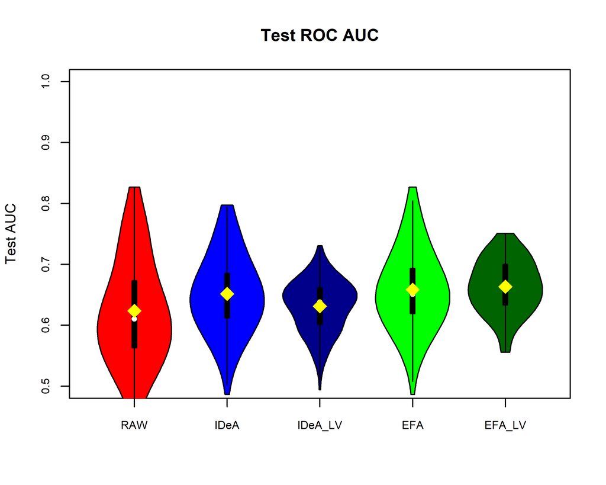

```r
par(op)
par(mfrow=c(1,1),cex=0.7)

AUCs <- list(RAW=RawAUCs,IDeA=IDeAAUCs,IDeA_LV=IDeAAUCs_LV,EFA=EFAAUCs,EFA_LV=EFAAUCs_LV)
vioplot(AUCs,
        ylim=c(0.5,1.0),
        ylab="Test AUC",
        main="Test ROC AUC",
        col=colors,
        cex.axis=0.8
)
#stripchart(diffAUC, method = "jitter", col = "gray",
#           vertical = TRUE, pch = 1, add = TRUE,cex=0.35)
points(1:length(AUCs),lapply(AUCs,mean), pch = 18, col = "yellow", cex = 2.25)
```

```r
par(op)


bp<- boxplot(AUCs,plot=FALSE)
bpstats <- as.data.frame(bp$stats)
rownames(bpstats) <- c("lower whisker","lower hinge","median","upper hinge","upper whisker")
colnames(bpstats) <- bp$names
pander::pander(bpstats)
```

|  | RAW | IDeA | IDeA_LV | EFA | EFA_LV |
| --- | --- | --- | --- | --- | --- |
| **lower whisker** | 0.463 | 0.504 | 0.519 | 0.523 | 0.556 |
| **lower hinge** | 0.563 | 0.612 | 0.601 | 0.619 | 0.633 |
| **median** | 0.610 | 0.648 | 0.638 | 0.651 | 0.663 |
| **upper hinge** | 0.673 | 0.685 | 0.662 | 0.693 | 0.700 |
| **upper whisker** | 0.827 | 0.791 | 0.730 | 0.803 | 0.751 |

### 2.2.3 Violin of ROC AUC Changes

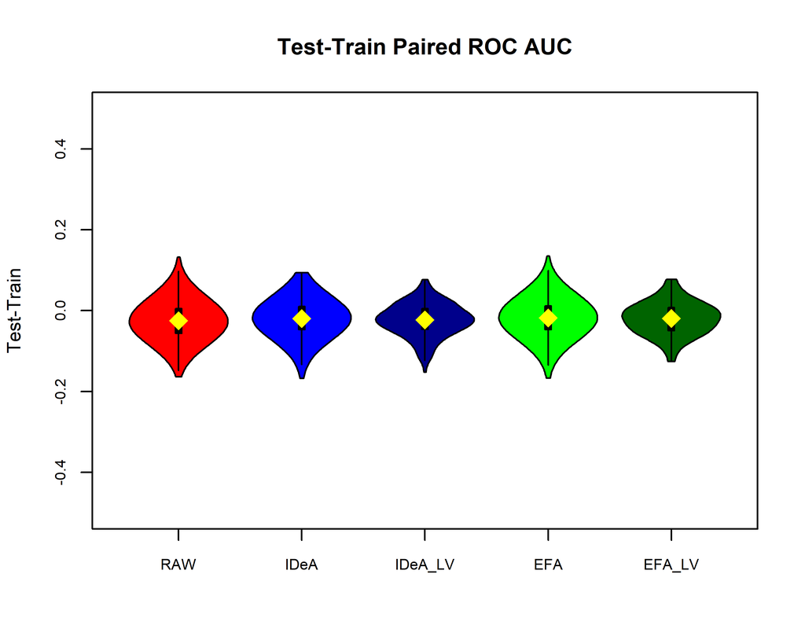

```r
par(op)
colors=c("red","blue","darkblue","green","darkgreen")
par(mfrow=c(1,1),cex=0.7)

diffAUC <- list(RAW=ChangeRawAUCs,IDeA=ChangeIDeAAUCs,IDeA_LV=ChangeIDeAAUCs_LV,EFA=ChangeEFAAUCs,EFA_LV=ChangeEFAAUCs_LV)
vioplot(diffAUC,
        ylim=c(-0.5,0.5),
        ylab="Test-Train",
        main="Test-Train Paired ROC AUC",
        col=colors,
        cex.axis=0.8
)
#stripchart(diffAUC, method = "jitter", col = "gray",
#           vertical = TRUE, pch = 1, add = TRUE,cex=0.35)
points(1:length(diffAUC),lapply(diffAUC,mean), pch = 18, col = "yellow", cex = 2.25)
```

```r
par(op)


bp<- boxplot(diffAUC,plot=FALSE)
bpstats <- as.data.frame(bp$stats)
rownames(bpstats) <- c("lower whisker","lower hinge","median","upper hinge","upper whisker")
colnames(bpstats) <- bp$names
pander::pander(bpstats)
```

|  | RAW | IDeA | IDeA_LV | EFA | EFA_LV |
| --- | --- | --- | --- | --- | --- |
| **lower whisker** | -0.14548 | -0.1330 | -0.11787 | -0.1330 | -0.12554 |
| **lower hinge** | -0.05601 | -0.0469 | -0.04640 | -0.0468 | -0.04920 |
| **median** | -0.02615 | -0.0184 | -0.02166 | -0.0168 | -0.01377 |
| **upper hinge** | 0.00529 | 0.0106 | 0.00474 | 0.0116 | 0.00735 |
| **upper whisker** | 0.09681 | 0.0938 | 0.07679 | 0.0968 | 0.07722 |

### 2.2.4 Violin of Overlap

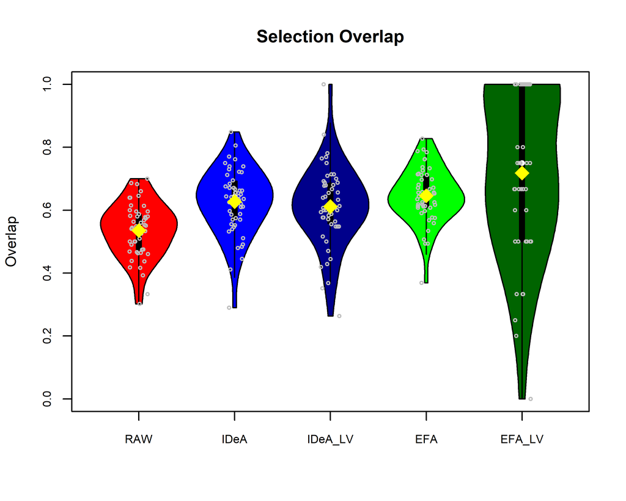

```r
par(op)
par(mfrow=c(1,1),cex=0.7)

posFind <- list(RAW=overlapRaw,IDeA=overlapIDeA,IDeA_LV=overlapIDeA_LV,EFA=overlapEFA,EFA_LV=overlapEFA_LV)
vioplot(posFind,
        ylim=c(0,1.0),
        ylab="Overlap",
        main="Selection Overlap",
        col=colors,
        cex.axis=0.8
)
stripchart(posFind, method = "jitter", col = "gray",
           vertical = TRUE, pch = 1, add = TRUE,cex=0.5)
points(1:length(posFind),lapply(posFind,mean), pch = 18, col = "yellow", cex = 2.25)
```

```r
par(op)


bp<- boxplot(posFind,plot=FALSE)
bpstats <- as.data.frame(bp$stats)
rownames(bpstats) <- c("lower whisker","lower hinge","median","upper hinge","upper whisker")
colnames(bpstats) <- bp$names
pander::pander(bpstats)
```

|  | RAW | IDeA | IDeA_LV | EFA | EFA_LV |
| --- | --- | --- | --- | --- | --- |
| **lower whisker** | 0.333 | 0.411 | 0.368 | 0.494 | 0.00 |
| **lower hinge** | 0.475 | 0.570 | 0.556 | 0.608 | 0.50 |
| **median** | 0.546 | 0.643 | 0.604 | 0.644 | 0.75 |
| **upper hinge** | 0.587 | 0.695 | 0.688 | 0.712 | 1.00 |
| **upper whisker** | 0.700 | 0.848 | 0.840 | 0.828 | 1.00 |

### 2.2.5 Violin of Booth Positive top

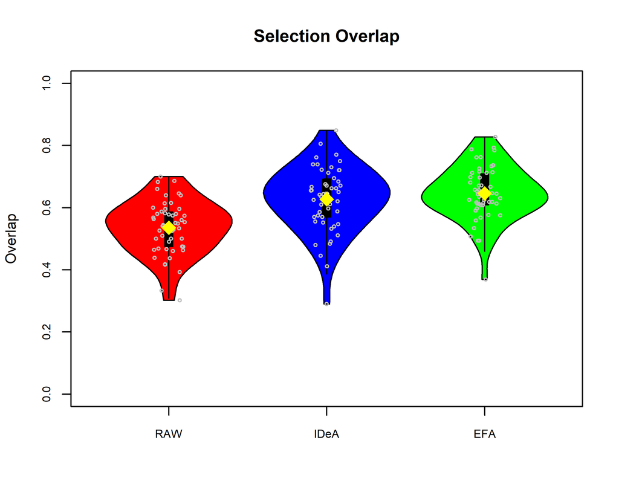

```r
par(op)
par(mfrow=c(1,1),cex=0.7)

posFind <- list(RAW=overlapRaw,IDeA=overlapIDeA,EFA=overlapEFA)
vioplot(posFind,
        ylim=c(0,1.0),
        ylab="Overlap",
        main="Selection Overlap",
        col=colors[c(1,2,4)],
        cex.axis=0.8
)
stripchart(posFind, method = "jitter", col = "gray",
           vertical = TRUE, pch = 1, add = TRUE,cex=0.5)
points(1:length(posFind),lapply(posFind,mean), pch = 18, col = "yellow", cex = 2.25)
```

```r
par(op)


bp<- boxplot(posFind,plot=FALSE)
bpstats <- as.data.frame(bp$stats)
rownames(bpstats) <- c("lower whisker","lower hinge","median","upper hinge","upper whisker")
colnames(bpstats) <- bp$names
pander::pander(bpstats)
```

|  | RAW | IDeA | EFA |
| --- | --- | --- | --- |
| **lower whisker** | 0.333 | 0.411 | 0.494 |
| **lower hinge** | 0.475 | 0.570 | 0.608 |
| **median** | 0.546 | 0.643 | 0.644 |
| **upper hinge** | 0.587 | 0.695 | 0.712 |
| **upper whisker** | 0.700 | 0.848 | 0.828 |